# Gráfico de Barras

DATAUNIRIO

Clique [aqui](https://dataunirio.github.io/GALERIA_DE_GRAFICOS/) para voltar a página principal.

Para que serve: O gráfico de barras é uma maneira de resumir a informação de uma variável qualitativa/categórica.

Uma variável é chamada qualitativa, também conhecida como categórica, se seus valores pertencem a uma coleção de classes não superpostas. Exemplos comuns incluem notas de letra de estudante (A, B, C, D ou F), classificação de algo (Baixo, médio ou alto), Sexo (Feminino ou Masculino).

Há vantagem do uso do gráfico de barras sobre o gráfico de pizza quando temos variáveis ordinais ou quando há muitas categorias de análise.

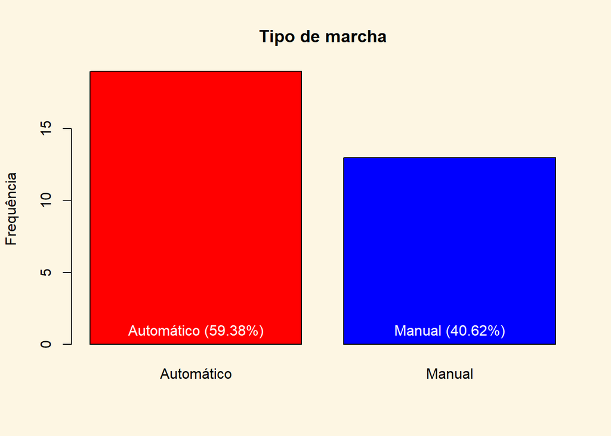

```r
data(mtcars)
mtcars <- within(mtcars, {
  am <- factor(am, labels=c('Automático','Manual'))
})
mtcars <- within(mtcars, {
  vs <- factor(vs, labels=c('Não','Sim'))
})
par(bg="#fdf6e3")

contagem = table(mtcars$am)
nomes = levels(mtcars$am)
porcent = round(prop.table(contagem)*100,2)
rotulo=paste(nomes," (",porcent,"%",")",sep="")
barras<-barplot(table(mtcars$am), ylab="Frequência", main="Tipo de marcha", col=c("red","blue"))
text(barras, 0, rotulo,cex=1,pos=3,col ="#ffffff")
```

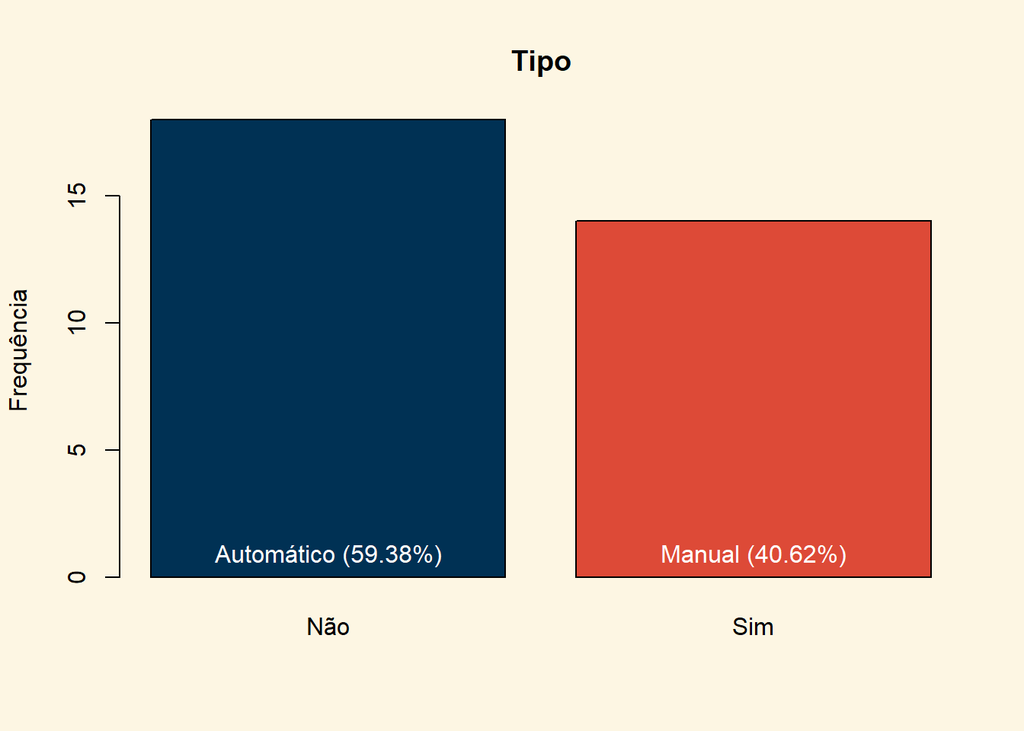

```r
contagem2 = table(mtcars$vs)
nomes2 = levels(mtcars$vs)
porcent2 = round(prop.table(contagem2)*100,2)
rotulo2=paste(nomes2," (",porcent2,"%",")",sep="")
barras2<-barplot(table(mtcars$vs), ylab="Frequência", main="Tipo", col=c("#003154","#dd4a37"))
text(barras2, 0, rotulo,cex=1,pos=3,col ="#ffffff")
```

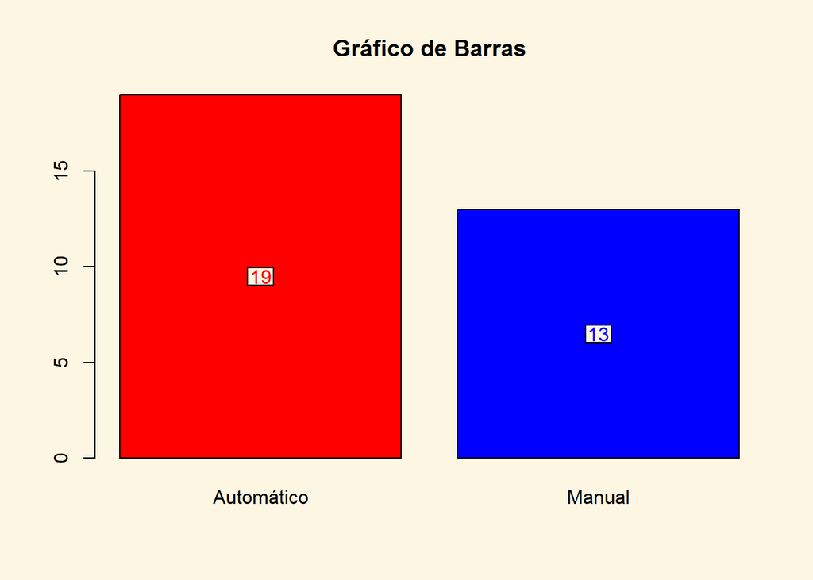

```r
par(bg="#fdf6e3")
library(plotrix)
barpos<-barplot(contagem,main="Gráfico de Barras",col=c("red","blue"))
barlabels(barpos,contagem,col=c("red","blue"))
```

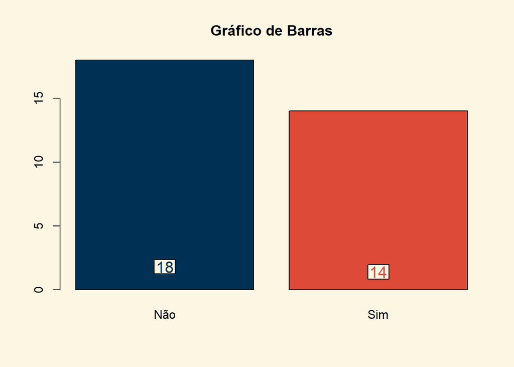

```r
barpos2<-barplot(contagem2,main="Gráfico de Barras", col=c("#003154","#dd4a37"))
barlabels(barpos2,contagem2,cex=1.3,prop=0.1, col=c("#003154","#dd4a37"))
```

# Gráficos de Barras “GAP”

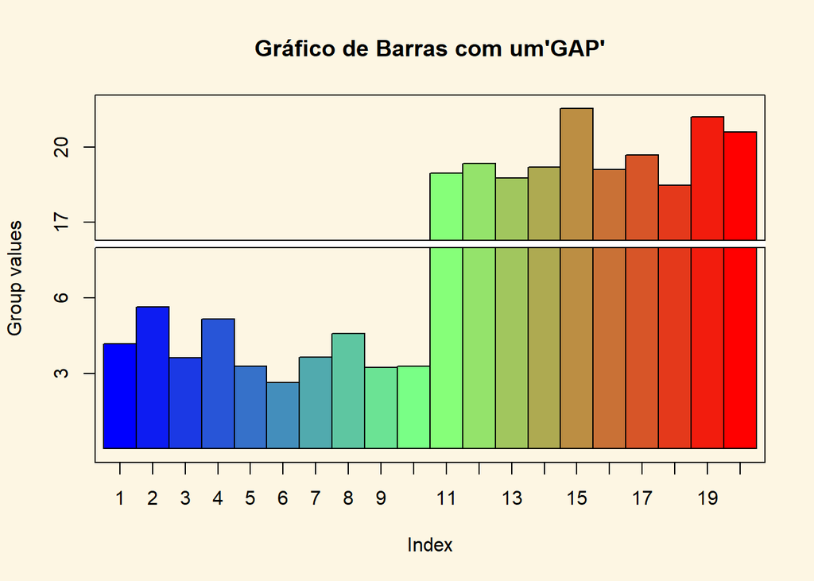

```r
library(RColorBrewer)
par(bg="#fdf6e3")
#display.brewer.all()
COR<-brewer.pal(4,"Dark2")
#COR

library(plotrix)
twogrp<-c(rnorm(10)+4,rnorm(10)+20)
 gap.barplot(twogrp,gap=c(8,16),xlab="Index",ytics=c(3,6,17,20),
  ylab="Group values",main="Gráfico de Barras com um'GAP'")
```

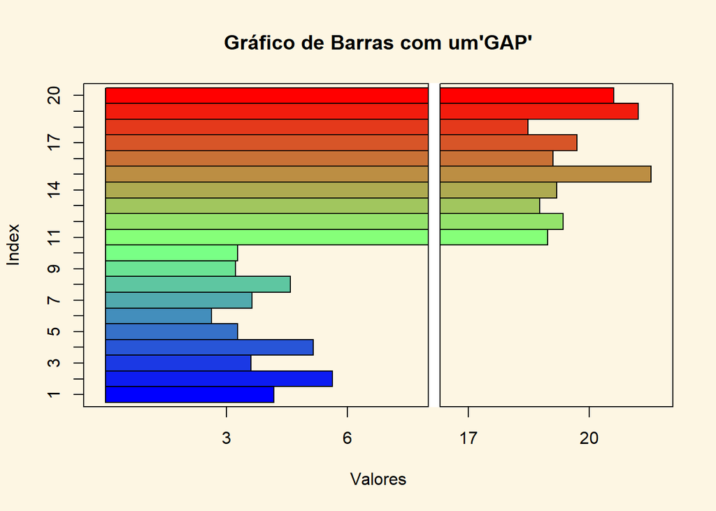

```r
gap.barplot(twogrp,gap=c(8,16),xlab="Index",ytics=c(3,6,17,20),
  ylab="Valores",horiz=TRUE,main="Gráfico de Barras com um'GAP'")
```

# Barras no ggplot2

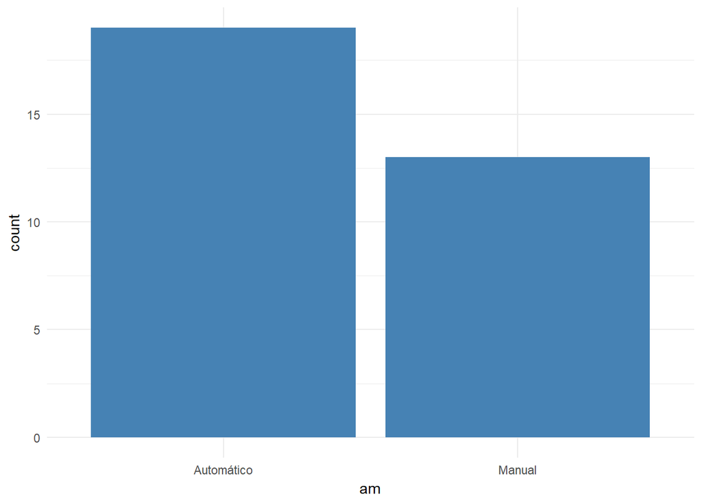

```r
library(ggplot2)
ggplot(data=mtcars, aes(x=am)) +
  geom_bar(stat="count", fill="steelblue")+
  theme_minimal()
```

```r
#install.packages('RCurl')
library(RCurl)
```

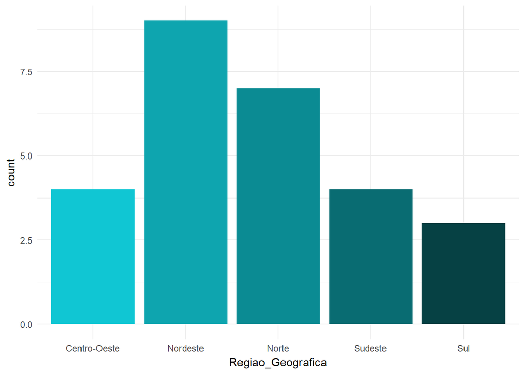

```r
x <- getURL("https://raw.githubusercontent.com/DATAUNIRIO/Base_de_dados/master/Estados.csv")
BaseUF <- read.csv(text=x, header=T, quote="", sep=";",dec = ",")
ggplot(data=BaseUF, aes(x=Regiao_Geografica)) +
  geom_bar(stat="count", fill=c("#10c6d3","#0ea5af","#0b8b93","#096c72","#064144"))+
  theme_minimal()
```

# Rótulos das Barras no ggplot2

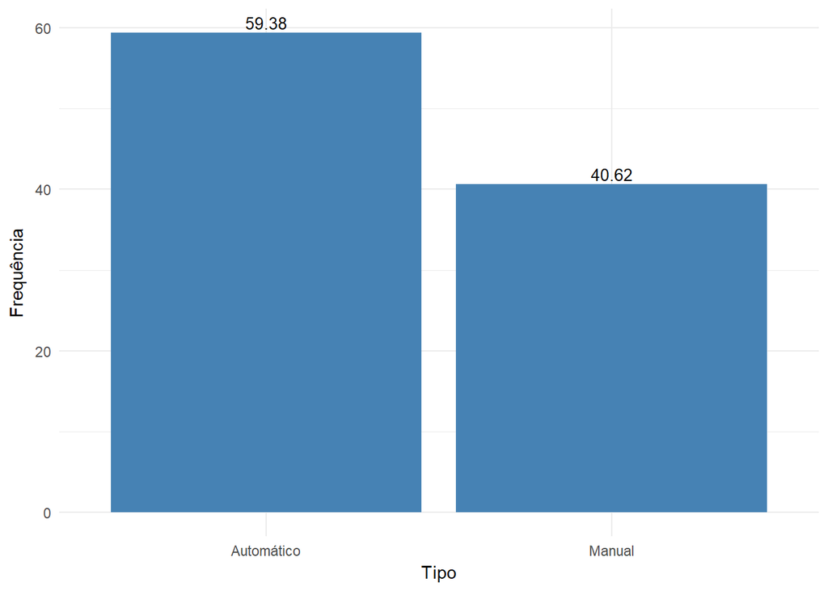

```r
dados = data.frame(round(prop.table(contagem)*100,2))
dados <- within(dados, {
  Var1 <- factor(Var1, labels=c('Automático','Manual'))
})
attach(dados)
dados <- dados[order(Freq),]
detach(dados)

# Fora das Barras
ggplot(data=dados, aes(x=Var1, y=Freq)) +
  geom_bar(stat="identity", fill="steelblue")+
  geom_text(aes(label=Freq), vjust=-0.3, size=3.5)+
   ylab("Frequência") +
   xlab("Tipo") +
   theme_minimal()
```

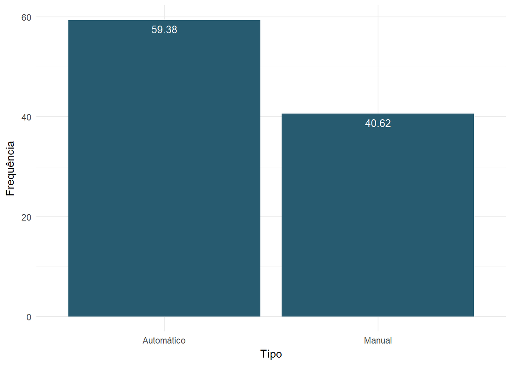

```r
# Dentro das Barras
ggplot(data=dados, aes(x=Var1, y=Freq)) +
  geom_bar(stat="identity", fill="#275b70")+
  geom_text(aes(label=Freq), vjust=1.6, color="white",size=3.5)+
  ylab("Frequência") +
  xlab("Tipo") +
  theme_minimal()
```

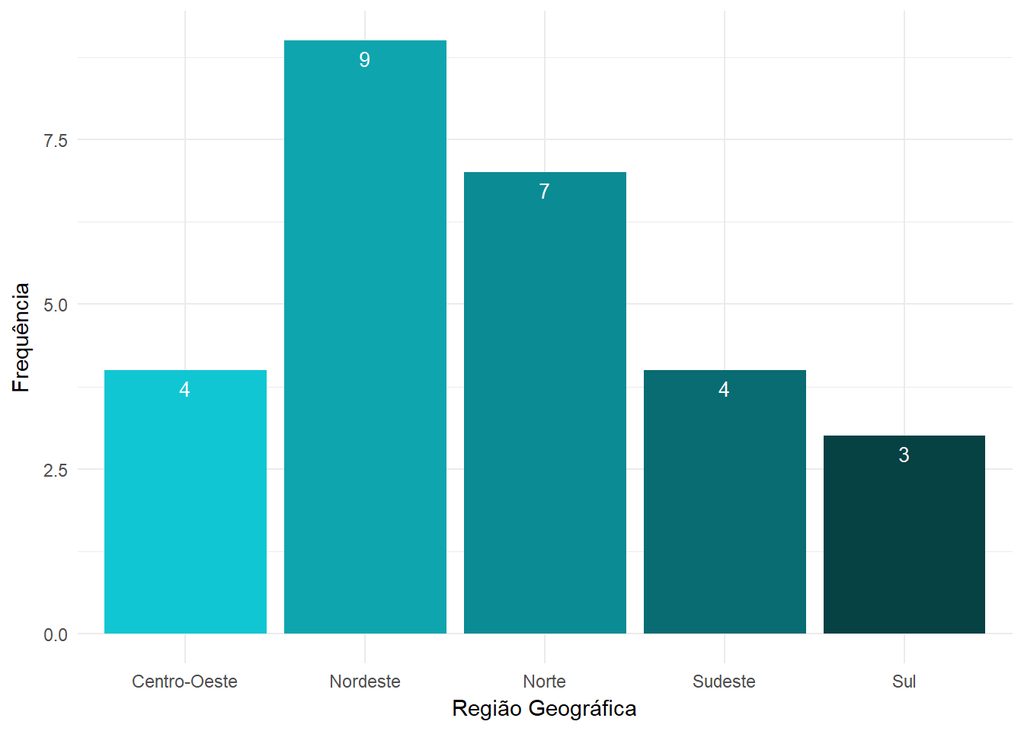

```r
ggplot(data=BaseUF, aes(x=Regiao_Geografica)) +
  geom_bar(stat="count", fill=c("#10c6d3","#0ea5af","#0b8b93","#096c72","#064144"))+
  geom_text(stat='count',aes(label=..count..),vjust=1.6, color="white",size=3.5)+
  ylab("Frequência") +
  xlab("Região Geográfica") +
  theme_minimal()
```

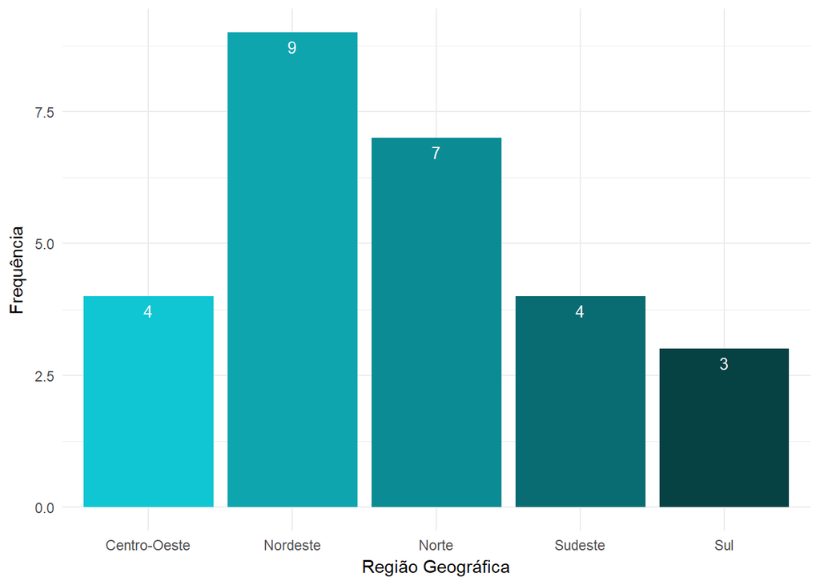

```r
ggplot(data=BaseUF, aes(x=Regiao_Geografica)) +
  geom_bar(stat="count", fill=c("#10c6d3","#0ea5af","#0b8b93","#096c72","#064144"))+
  geom_text(stat="count",aes(label=..count..),vjust=1.6, color="white",size=3.5)+
  ylab("Frequência") +
  xlab("Região Geográfica") +
  theme_minimal()
```

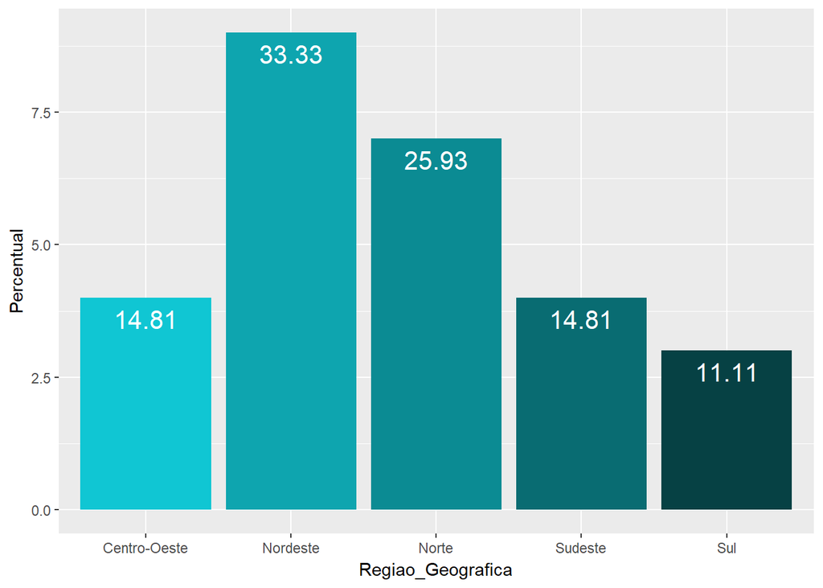

```r
ggplot(data=BaseUF, aes(x=Regiao_Geografica)) +
  geom_bar(stat="count", fill=c("#10c6d3","#0ea5af","#0b8b93","#096c72","#064144"))+
geom_text(aes(label = round(prop.table(..count..)*100,2), y= ..count.. ), stat= "count", vjust=1.6, color="white",size=5.5) +
  labs(y = "Percentual", fill="Regiao_Geografica")
```

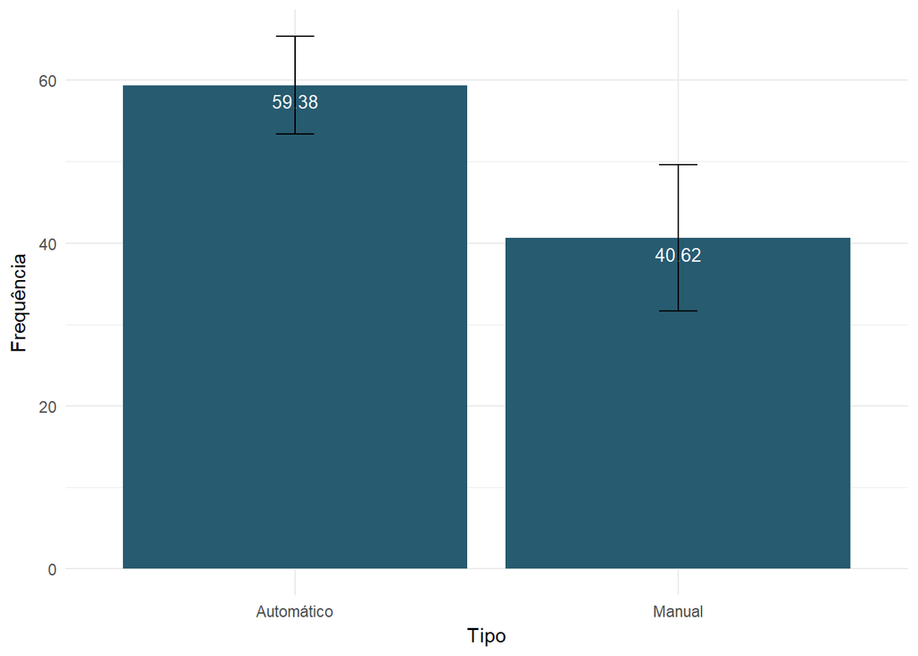

```r
error <- c(9, 6)
# adding error bars
plt<-ggplot(data=dados, aes(x=Var1, y=Freq)) +
  geom_bar(stat="identity", fill="#275b70")+
  geom_text(aes(label=Freq), vjust=1.6, color="white",size=3.5)+
  ylab("Frequência") +
  xlab("Tipo") +
  theme_minimal()

plt +  geom_errorbar(aes(ymin=Freq-error, ymax=Freq+error), width=.1, position=position_dodge(.1))
```

# Alternativas ao Gráfico de Barras

## Gráficos de pontos “Dotplot” para variáveis discretas.

Descrição. Um gráfico de pontos consiste em pontos de dados plotados em uma escala bastante simples, geralmente usando círculos preenchidos. É um tipo de gráfico utilizado na estatística para conjuntos de dados relativamente pequenos onde os valores se enquadram em uma série de barras discretas (categorias). Um gráfico de pontos é semelhante a um gráfico de barras porque a altura de cada “barra” de pontos é igual ao número de itens em uma categoria específica.

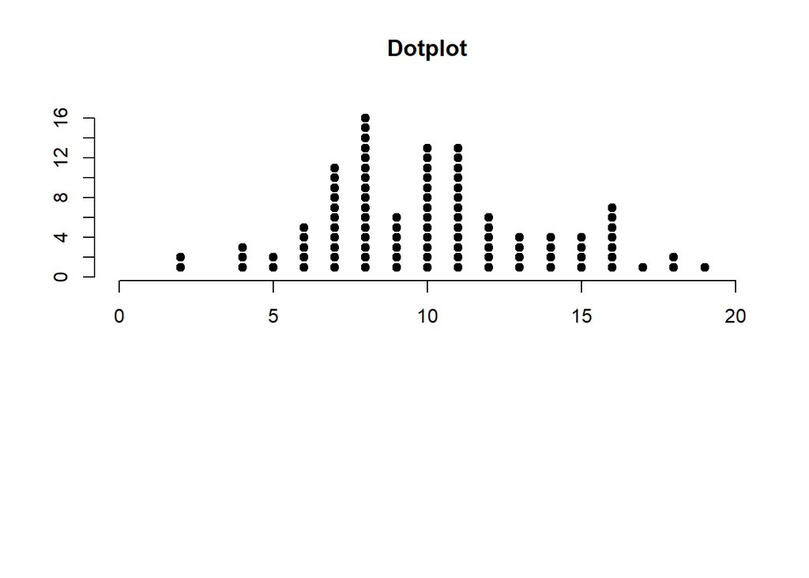

```r
library(plotrix)
x <- rpois(100,10)
dotplot.mtb(x,yaxis=TRUE,main="Dotplot")
```

## Gráfico com Barras preenchidas com símbolos

Descrição. Produz um gráfico de barras onde cada unidade de ‘barra’ é preenchida com o número de símbolos igual ao tamanho da barra.

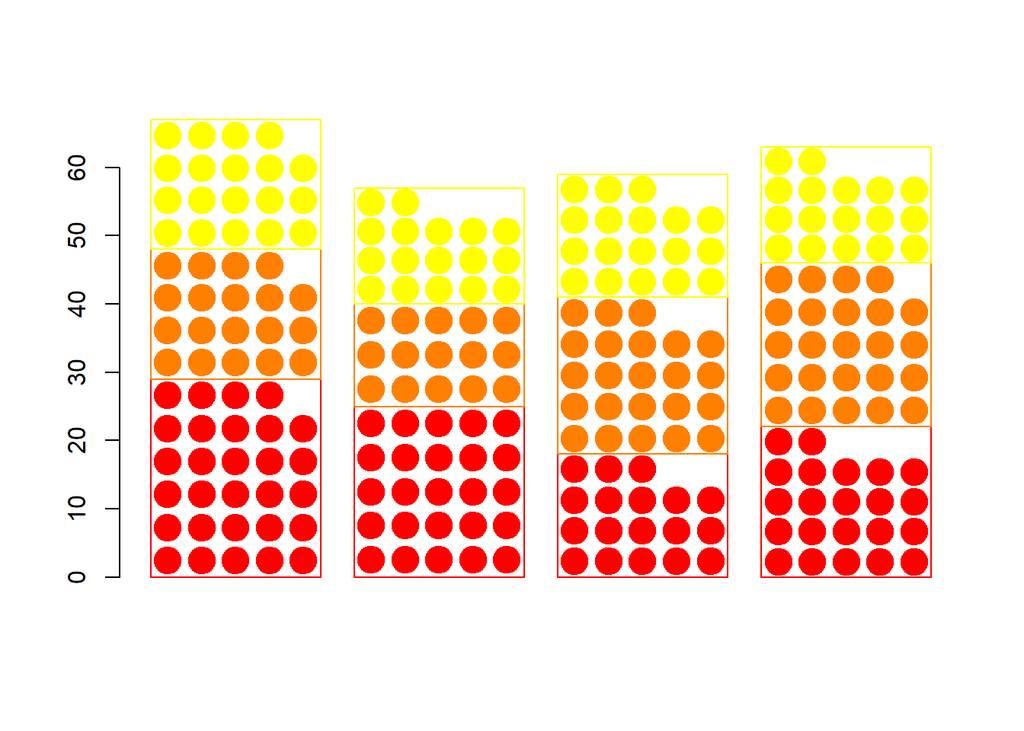

```r
set.seed(1001)
bvals <- matrix(rpois(12,20),nrow=3)
b <- symbolbarplot(bvals)
```

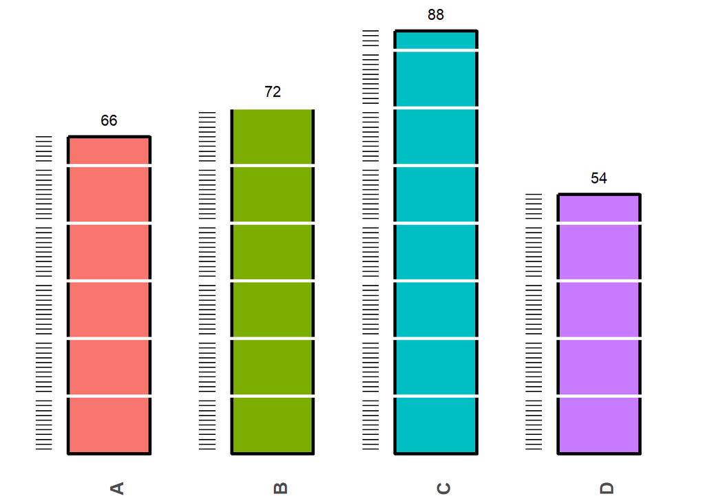

```r
require(ggplot2)

# function
ruler.bar.plot <-function(gg, nn, mjtick =1, mntick = 0.2, mjtickcol = "black", mntickcol = "white"){
seq.list<-list()
for(i in 1:length(gg)){
  ystart<-seq(mntick ,gg[i],mntick )
  yend<-ystart
  xstart<-rep(i-0.45,length(ystart))
  xend<-xstart+0.1
  nam.val<-c(nn[i],rep(NA,length(ystart)-1))
  numb.val<-c(gg[i],rep(NA,length(ystart)-1))
  seq.list[[i]]<-data.frame(nam.val,numb.val,xstart,xend,ystart,yend)
}
df<-as.data.frame(do.call(rbind, seq.list))
p <- ggplot(df, aes(nam.val))
p + geom_bar(aes(y=numb.val,fill=nam.val),stat="identity",width=0.5,color=mjtickcol,lwd=1.1) +
        geom_segment(aes(x=xstart,y=ystart,xend=xend,yend=yend), color=mjtickcol) +
        ylim(c(0,max(gg)+0.5))  + scale_x_discrete(limits= nn) +
            geom_hline(yintercept=seq(mjtick,max(gg),mjtick),color=mntickcol,lwd=1.1)+   geom_text(aes (y = numb.val, label = numb.val), vjust= - 1 ) +
    guides(fill=FALSE) +
         theme_bw()+
    theme(axis.title=element_blank(),
               axis.text.y=element_blank(),
               axis.text.x=element_text(angle=90,face="bold",size=rel(1.5)),
               axis.ticks=element_blank(),
               panel.background = element_rect(fill = mntickcol),
               panel.border=element_blank(),
               panel.grid=element_blank(),
               legend.position = "none")
}

# human height in inches, ticking done at each 12
htinch <- c(66, 72, 88, 54)
id <- c("A", "B", "C", "D")
ruler.bar.plot(htinch, id, mjtick =12, mntick = 1,  mjtickcol = "black", mntickcol = "white")
```

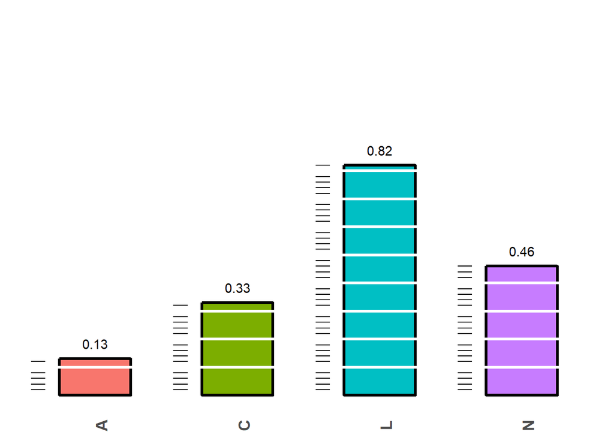

```r
VV = c(0.13, 0.33, 0.82, 0.46)
LV = c("A", "C", "L", "N")
ruler.bar.plot(VV, LV, mjtick =0.1, mntick = 0.02,  mjtickcol = "black", mntickcol = "white")
```

# Gráfico de Barras Circular

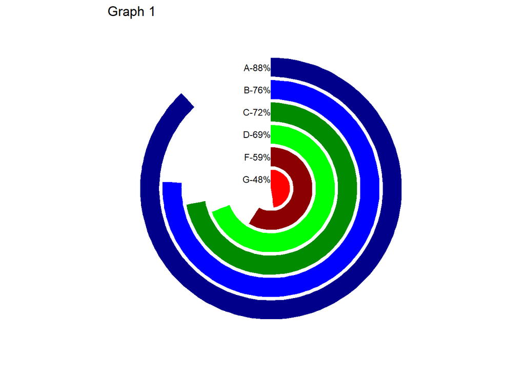

```r
#circular bar plot
library(ggplot2)
#DATA
catg <- c("A", "B", "C", "D", "F", "G")
percent <- c(88, 76, 72, 69, 59, 48)
category <- paste (catg, "-", percent, "%", sep = "")
myd <-data.frame(category,percent)
# converting to factor and applying to
#levels to set proper order of bars
myd$category <-factor(myd$category,levels=rev(myd$category))
# plot
plt <- ggplot(myd, aes(x = category, y = percent,fill = category)) + geom_bar(width = 0.85, stat="identity") +    coord_polar(theta = "y") +    xlab("") + ylab("") +
    ylim(c(0,100)) + ggtitle("Graph 1") +    geom_text(data = myd, hjust = 1, size = 3, aes(x = category, y = 0, label = category))

plt +  scale_fill_manual(values = c("red1","red4", "green1", "green4", "blue1", "blue4")) + theme_minimal() + theme(legend.position = "none",panel.grid.major = element_blank(),panel.grid.minor = element_blank(),          axis.line = element_blank(),axis.text.y = element_blank(),          axis.text.x = element_blank(), axis.ticks = element_blank())
```

Clique [aqui](https://dataunirio.github.io/GALERIA_DE_GRAFICOS/) para voltar a página principal.